# The Advantages of Energy Regression for Mediation

```r
# Optional: enable parallel cross-fitting
library(future)
plan(multisession)
```

## Introduction

Energy regression (`engression`) learns the **full conditional distribution** $P(Y|X)$, whereas standard mediation tools like `crumble` (via `SuperLearner`) typically target only the **conditional mean** $E[Y|X]$. This vignette demonstrates scenarios where this difference matters for obtaining correct causal estimates, comparing `dma` against `crumble` with a GLM learner on each scenario.

## 1. The Bimodal Mediator Challenge

In many settings, a behavior (the mediator) is bimodal: individuals are either “high” or “low,” but rarely at the average.

**Scenario**:

- $A=0 \implies M \sim N(0, 0.5^2)$
- $A=1 \implies M$ is a mixture: $50\% \sim N(-2, 0.5^2)$ and $50\% \sim N(2, 0.5^2)$
- $Y = M^2 + \epsilon$
- **Note**: $E[M|A=1] = 0$, the same as $E[M|A=0]$
- **True Indirect Effect**: $E[M^2|A=1] - E[M^2|A=0] = (2^2 + 0.5^2) - (0^2 + 0.5^2) = \mathbf{4.0}$

A mean-based learner sees that the mean of $M$ is zero for both groups and concludes there is zero indirect effect. Engression captures the bimodal structure and recovers the true effect.

```r
library(dma)
library(crumble)

set.seed(123)
n <- 1000
A <- rbinom(n, 1, 0.5)
M <- ifelse(A == 0, rnorm(n, 0, 0.5),
            ifelse(runif(n) > 0.5, rnorm(n, -2, 0.5), rnorm(n, 2, 0.5)))
Y <- M^2 + rnorm(n, 0, 0.5)
data <- data.frame(A, M, Y, W = rnorm(n))

d0 <- \(data, trt) 0
d1 <- \(data, trt) 1

# dma (Distributional)
res_dma <- dma(
  data = data, trt = "A", outcome = "Y", mediators = "M", covar = "W",
  d0 = d0, d1 = d1, effect = "N",
  control = dma_control(crossfit_folds = 1L, num_epochs = 200L, riesz_epochs = 50L)
)

# crumble (Mean-based GLM)
res_crumble <- crumble(
  data = data, trt = "A", outcome = "Y", mediators = "M", covar = "W",
  d0 = d0, d1 = d1, effect = "N",
  learners = "glm",
  control = crumble_control(crossfit_folds = 1L, epochs = 20L)
)
```

| Estimand | Truth | dma | crumble (GLM) |
| --- | --- | --- | --- |
| NIE | 4.0 | 4.992 | -0.240 |

### Oracle counterfactual distributions

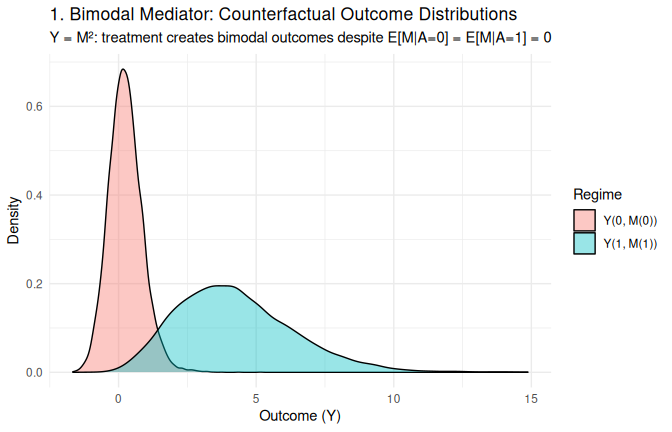

```r
set.seed(42)
n_o <- 10000

# Y(0, M(0)): M ~ N(0, 0.5)
M0 <- rnorm(n_o, 0, 0.5)
Y0 <- M0^2 + rnorm(n_o, 0, 0.5)

# Y(1, M(1)): M ~ 50% N(-2, 0.5) + 50% N(2, 0.5)
M1 <- ifelse(runif(n_o) > 0.5, rnorm(n_o, -2, 0.5), rnorm(n_o, 2, 0.5))
Y1 <- M1^2 + rnorm(n_o, 0, 0.5)

oracle_1 <- rbind(
  data.frame(Y = Y0, Regime = "Y(0, M(0))"),
  data.frame(Y = Y1, Regime = "Y(1, M(1))")
)

ggplot(oracle_1, aes(x = Y, fill = Regime)) +
  geom_density(alpha = 0.4) +
  labs(title = "1. Bimodal Mediator: Counterfactual Outcome Distributions",
       subtitle = "Y = M²: treatment creates bimodal outcomes despite E[M|A=0] = E[M|A=1] = 0",
       x = "Outcome (Y)", y = "Density") +
  theme_minimal()
```

The bimodal mediator under treatment creates a right-shifted, heavy-tailed outcome distribution centered around $M^2 \approx 4$, while the control outcome is concentrated near zero. Mean-based methods miss this entirely because $E[M]$ doesn’t change.

## 2. Heteroskedasticity (Variance as Signal)

Treatment often changes the **variance** or **spread** of a behavior without shifting its mean.

**Scenario**:

- $M|A=0 \sim N(0, 1^2)$
- $M|A=1 \sim N(0, 3^2)$
- $Y = M^2 + \epsilon$
- **True Indirect Effect**: $E[M^2|A=1] - E[M^2|A=0] = 3^2 - 1^2 = \mathbf{8.0}$

```r
set.seed(123)
n <- 1000
A <- rbinom(n, 1, 0.5)
M <- rnorm(n, 0, sd = ifelse(A == 0, 1, 3))
Y <- M^2 + rnorm(n, 0, 0.5)
data <- data.frame(A, M, Y, W = rnorm(n))

# dma
res_dma_het <- dma(
  data = data, trt = "A", outcome = "Y", mediators = "M", covar = "W",
  d0 = d0, d1 = d1, effect = "N",
  control = dma_control(crossfit_folds = 1L, num_epochs = 200L, riesz_epochs = 50L)
)

# crumble
res_crumble_het <- crumble(
  data = data, trt = "A", outcome = "Y", mediators = "M", covar = "W",
  d0 = d0, d1 = d1, effect = "N",
  learners = "glm",
  control = crumble_control(crossfit_folds = 1L, epochs = 20L)
)
```

| Estimand | Truth | dma | crumble (GLM) |
| --- | --- | --- | --- |
| NIE | 8.0 | 7.721 | -0.137 |

### Oracle counterfactual distributions

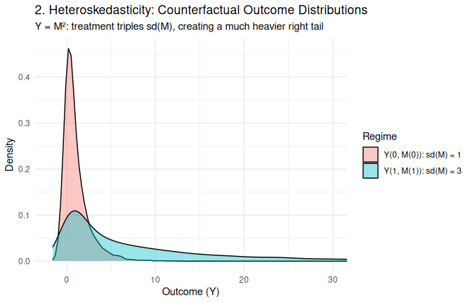

```r
set.seed(42)
n_o <- 10000

# Y(0): M ~ N(0, 1), Y = M²
M0 <- rnorm(n_o, 0, 1)
Y0 <- M0^2 + rnorm(n_o, 0, 0.5)

# Y(1): M ~ N(0, 3), Y = M²
M1 <- rnorm(n_o, 0, 3)
Y1 <- M1^2 + rnorm(n_o, 0, 0.5)

oracle_2 <- rbind(
  data.frame(Y = Y0, Regime = "Y(0, M(0)): sd(M) = 1"),
  data.frame(Y = Y1, Regime = "Y(1, M(1)): sd(M) = 3")
)

ggplot(oracle_2, aes(x = Y, fill = Regime)) +
  geom_density(alpha = 0.4) +
  coord_cartesian(xlim = c(-2, 30)) +
  labs(title = "2. Heteroskedasticity: Counterfactual Outcome Distributions",
       subtitle = "Y = M²: treatment triples sd(M), creating a much heavier right tail",
       x = "Outcome (Y)", y = "Density") +
  theme_minimal()
```

## 3. Robustness to Heavy-Tailed Noise (Outliers)

Energy regression is more robust to extreme outliers than standard mean squared error.

**Scenario**:

- Confounder $W \sim \text{Cauchy}(0, 1)$ (clipped to $[-20, 20]$)
- $Y$ and $M$ are linear in $A$ and $W$
- **True Indirect Effect**: $\mathbf{1.0}$

```r
set.seed(123)
n <- 500
W <- rcauchy(n)
W <- pmax(pmin(W, 20), -20)
A <- rbinom(n, 1, plogis(0.1 * W))
M <- A + 0.5 * W + rnorm(n)
Y <- A + M + 0.5 * W + rnorm(n)
data <- data.frame(A, M, Y, W)

# dma
res_dma_heavy <- dma(
  data = data, trt = "A", outcome = "Y", mediators = "M", covar = "W",
  d0 = d0, d1 = d1, effect = "N",
  control = dma_control(crossfit_folds = 1L, num_epochs = 200L, riesz_epochs = 50L)
)

# crumble
res_crumble_heavy <- crumble(
  data = data, trt = "A", outcome = "Y", mediators = "M", covar = "W",
  d0 = d0, d1 = d1, effect = "N",
  learners = "glm",
  control = crumble_control(crossfit_folds = 1L, epochs = 20L)
)
```

| Estimand | Truth | dma | crumble (GLM) |
| --- | --- | --- | --- |
| NIE | 1.0 | 1.067 | 1.049 |

### Oracle counterfactual distributions

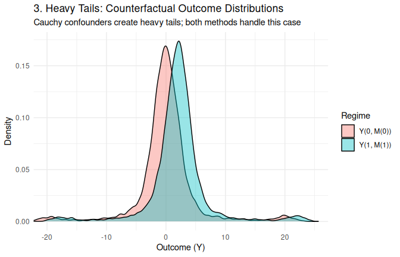

```r
set.seed(42)
n_o <- 10000
W_o <- rcauchy(n_o)
W_o <- pmax(pmin(W_o, 20), -20)

# Y(0): A=0, M = 0.5W + eps, Y = M + 0.5W + eps
M0 <- 0.5 * W_o + rnorm(n_o)
Y0 <- M0 + 0.5 * W_o + rnorm(n_o)

# Y(1): A=1, M = 1 + 0.5W + eps, Y = 1 + M + 0.5W + eps
M1 <- 1 + 0.5 * W_o + rnorm(n_o)
Y1 <- 1 + M1 + 0.5 * W_o + rnorm(n_o)

oracle_3 <- rbind(
  data.frame(Y = Y0, Regime = "Y(0, M(0))"),
  data.frame(Y = Y1, Regime = "Y(1, M(1))")
)

ggplot(oracle_3, aes(x = Y, fill = Regime)) +
  geom_density(alpha = 0.4) +
  coord_cartesian(xlim = c(-20, 25)) +
  labs(title = "3. Heavy Tails: Counterfactual Outcome Distributions",
       subtitle = "Cauchy confounders create heavy tails; both methods handle this case",
       x = "Outcome (Y)", y = "Density") +
  theme_minimal()
```

With Cauchy confounders, both outcome distributions have very heavy tails. The treatment shifts the location by 2 (direct + indirect). Both dma and crumble handle this linear case well — the challenge here is robustness to outliers, not distributional complexity.

## 4. Extreme Treatment Shifts (Extrapolation)

Engression maintains the structural relationship of the data better than many ML learners when shifting far outside the training range.

**Scenario**: Shift $A$ by +5 units (standard deviation is 1).

- **True ATE**: $\mathbf{5.0}$

```r
set.seed(123)
n <- 1000
A <- rnorm(n)
M <- A + rnorm(n, 0, 0.5)
Y <- M + rnorm(n, 0, 0.5)
data <- data.frame(A, M, Y, W = rnorm(n))

d_extrap <- \(data, trt) data[[trt]] + 5

# dma
res_dma_extrap <- dma(
  data = data, trt = "A", outcome = "Y", mediators = "M", covar = "W",
  d0 = \(data, trt) data[[trt]],
  d1 = d_extrap, effect = "N",
  control = dma_control(crossfit_folds = 1L, num_epochs = 200L, riesz_epochs = 50L)
)

# crumble
res_crumble_extrap <- crumble(
  data = data, trt = "A", outcome = "Y", mediators = "M", covar = "W",
  d0 = \(data, trt) data[[trt]],
  d1 = d_extrap, effect = "N",
  learners = "glm",
  control = crumble_control(crossfit_folds = 1L, epochs = 20L)
)
```

| Estimand | Truth | dma | crumble (GLM) |
| --- | --- | --- | --- |
| ATE | 5.0 | 4.582 | 9.814 |

### Oracle counterfactual distributions

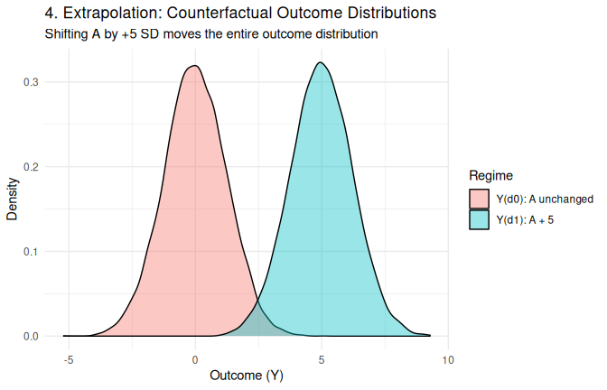

```r
set.seed(42)
n_o <- 10000
A_o <- rnorm(n_o)

# Y(d0): A unchanged, M = A + eps, Y = M + eps
M_d0 <- A_o + rnorm(n_o, 0, 0.5)
Y_d0 <- M_d0 + rnorm(n_o, 0, 0.5)

# Y(d1): A shifted by +5, M = (A+5) + eps, Y = M + eps
M_d1 <- (A_o + 5) + rnorm(n_o, 0, 0.5)
Y_d1 <- M_d1 + rnorm(n_o, 0, 0.5)

oracle_4 <- rbind(
  data.frame(Y = Y_d0, Regime = "Y(d0): A unchanged"),
  data.frame(Y = Y_d1, Regime = "Y(d1): A + 5")
)

ggplot(oracle_4, aes(x = Y, fill = Regime)) +
  geom_density(alpha = 0.4) +
  labs(title = "4. Extrapolation: Counterfactual Outcome Distributions",
       subtitle = "Shifting A by +5 SD moves the entire outcome distribution",
       x = "Outcome (Y)", y = "Density") +
  theme_minimal()
```

The +5 SD shift moves the outcome distribution by exactly 5 units. The challenge is that the shifted regime lies far outside the training data. Engression’s StoNet architecture extrapolates the structural relationship $Y = M + \epsilon$, $M = A + \epsilon$ correctly, while crumble’s GLM nearly doubles the true effect.

## Summary

| Scenario | Estimand | Truth | dma | crumble (GLM) | Why engression helps |
| --- | --- | --- | --- | --- | --- |
| Bimodal mediator | NIE | 4.0 | 4.992 | -0.240 | Captures distributional shift, not just mean |
| Heteroskedasticity | NIE | 8.0 | 7.721 | -0.137 | Detects variance change as causal pathway |
| Heavy-tailed confounders | NIE | 1.0 | 1.067 | 1.049 | Energy score is more robust than MSE |
| Extrapolation (+5 SD) | ATE | 5.0 | 4.582 | 9.814 | StoNet architecture extrapolates better |

## References

- Liu, R., Williams, N., Rudolph, K., & Diaz, I. (2024). General Mediation Analysis. arXiv:2408.14620.
- Shen, X. & Meinshausen, N. (2024). Engression: Extrapolation through the Lens of Distributional Regression. *JMLR*.